# Entendendo os Dados

Caynan Sousa

2/13/2017

## Introdução

Com base em alguns dados que temos sobre os alunos de computação da UFCG, queremos então poder treinar um classificador que seja capaz de responder a seguinte pergunta: *“Após um(a) aluno(a) ter terminado o primeiro período, ele(a) continuará no curso ou não?”*

```r
# rename columns
colnames(data) <- c("student_id", "course_id", "course", "year", "term", "mean", "dropped")

# reshape data
# - only one entry per student_id
# - reshape course mean into column

# get only one entry per student
unique.data <- data %>%
  group_by(student_id) %>% select(student_id, dropped, year, term) %>% unique()

# reshape courses into columns
data.reshaped.by.course <- data %>%
  group_by(student_id, course) %>%
  ungroup() %>%
  select(student_id, course, mean) %>%
  mutate(course = as.factor(gsub(" ", ".", course))) %>%
  dcast(student_id ~ course, mean)
# merge the two DFs
data <- merge(unique.data, data.reshaped.by.course)
```

## Perguntas

Afim de melhor entender os nossos dados, iremos buscar responder algumas perguntas.

### Em qual ano houve mais evasões?

Primeiro vamos criar uma nova variavel `num_dropouts` que irá conter para cada ano em nosso conjunto de dados: o número de alunos matriculados, número de evasões e a proporção de evasões em relação ao número total de alunos.

```r
num_dropouts <- data %>%
  group_by(year) %>%
  summarise(num_students = n(),
            num_dropouts = sum(dropped),
            proportion = num_dropouts / num_students)
```

Podemos ver que o ano com o maior número de desistências foi o ano de 2011 com nove evasões.

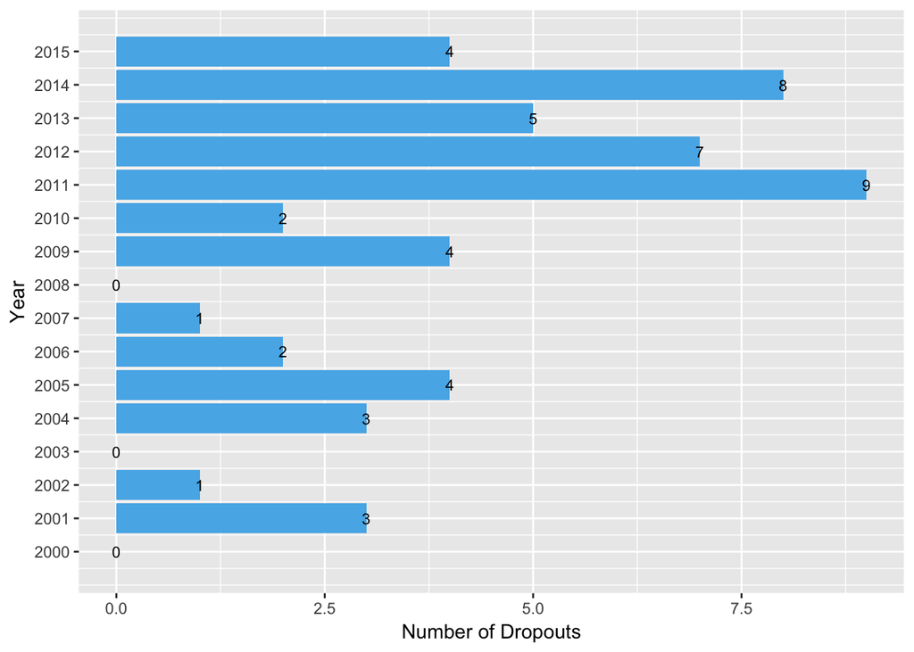

Esse número por si só não nós da uma informação confiavel, já que a quantidade de alunos em cada semestre não é o mesmo. Portanto afim de termos um valor mais confiável iremos ver também a proporção de evasões e o total de alunos para cada ano.

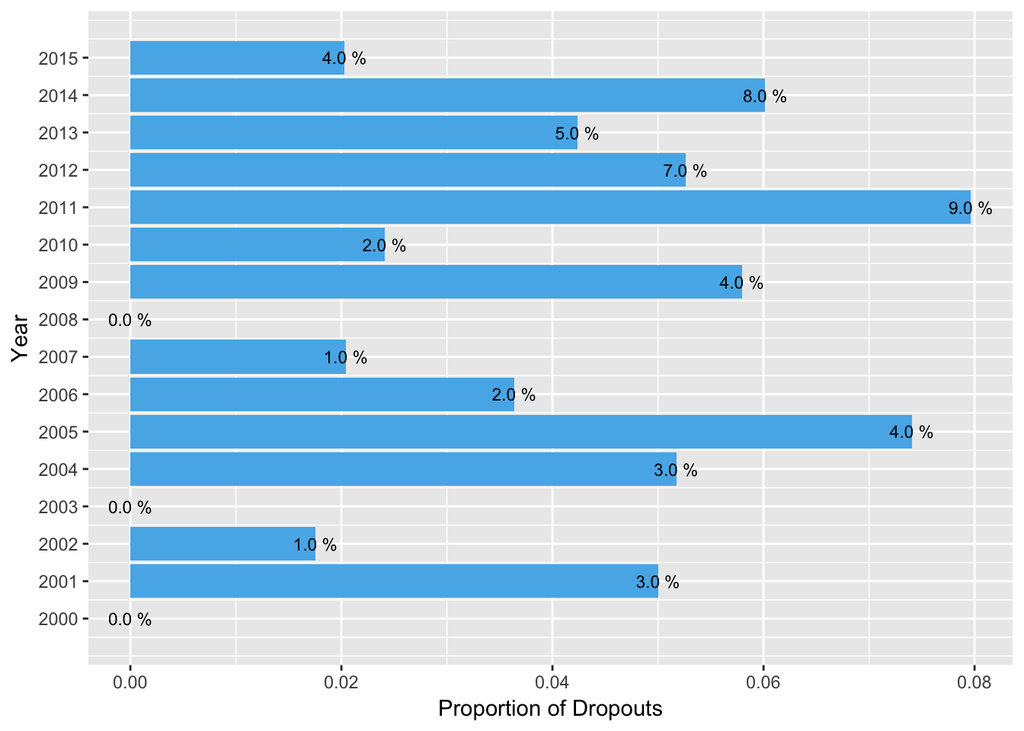

Conhecidentemente a proporção de evasão no ano de 2011 tambem foi o maior dentre os 15 anos observados.

### Qual a distribuição das classes em nossos dados?

Aproveitando de nossa tabela modificada com o número de alunos por ano e de evasões, podemos fazer um agrupamento afim de descobrirmos o total ao longo dos 15 anos de dados observados.

```r
total_dropouts <- num_dropouts %>%
  ungroup() %>%
  summarise(total_students = sum(num_students),
            total_dropouts = sum(num_dropouts))

total_dropouts.melt <- total_dropouts %>%
  melt(variable.name="data_class", value.name="total_count")
```

Podemos ver que a diferença entre o total de alunos e o número de alunos que desistiram é gritante, temos uma proporção de 25:1 entre alunos matriculados e evasões.

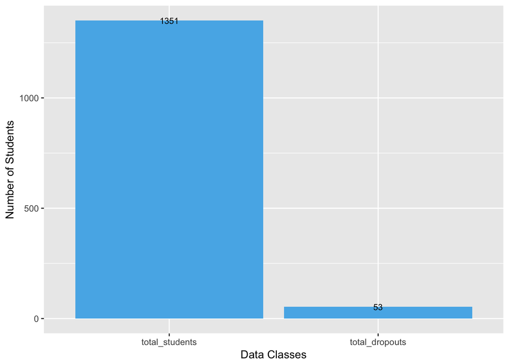

### Há desbalanceamento das classes (isto é, uma classe tem muito mais instâncias que outra)?

Sim, existe um desbalançeamento das classes, dentre 1351 alunos temos 53 que evadiram o curso no primeiro semestre e 1298 que continuaram no curso apos o primeiro periodo, o que podemos ver como uma proporcao de aproximadamente 1:25, ou seja em nossos dados para cada entrada onde o aluno evadiu temos aproximadamente 25 alunos que nao evadiram.

A presença desbalanceamento de classes afeta fortemente a maioria dos algoritmos de classificação, ja que os mesmos tenderão a desconsiderar o peso da classe minoritaria (alunos que evadiram), criando um viés de classificação para a classe marjoritaria nos dados (alunos que não evadiram).

## Computando Novos Dados

Afim de obtermor melhores resultados iremos pre-computar algumas variaveis que poderão então ser utilizadas em algoritmos de classificação.

Uma boa métrica para utilizarmos é o coeficiênte de rendimento acadêmico (CRA), e talvez saber em separado o CRA para disciplinas do DSC e do DME.

```r
all.courses <- c("Álgebra.Vetorial.e.Geometria.Analítica", "Cálculo.Diferencial.e.Integral.I","Introdução.à.Computação",
             "Laboratório.de.Programação.I", "Leitura.e.Produção.de.Textos", "Programação.I")
dme.courses <- c("Álgebra.Vetorial.e.Geometria.Analítica", "Cálculo.Diferencial.e.Integral.I")
dsc.courses <- c("Cálculo.Diferencial.e.Integral.I","Introdução.à.Computação", "Laboratório.de.Programação.I", "Programação.I")

# this only work because all courses has the same amount of credits
data$cra <- rowSums(data[,all.courses], na.rm = TRUE) / length(all.courses)
data$cra_dme <- rowSums(data[,dme.courses], na.rm = TRUE) / length(dme.courses)
data$cra_dsc <- rowSums(data[,dsc.courses], na.rm = TRUE) / length(dsc.courses)
```

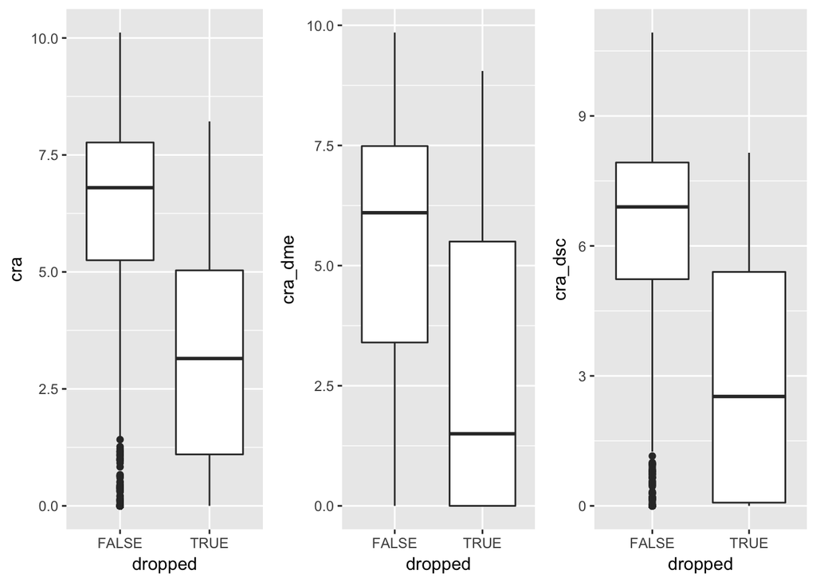